# House Price Prediction in Boulder, CO

## 4.8 Map of MAPE by neighborhood

In order to account for the impact of neighborhood discussed above, we make a new model that contains the neighborhood information, and analyze the distribution of MAPE across tracts.

### 4.8.1 Choropleth Map of MAPE

From the choropleth map below, we can see that the western district has higher and evenly distributed MAPE, while south eastern county has lower MAPE.

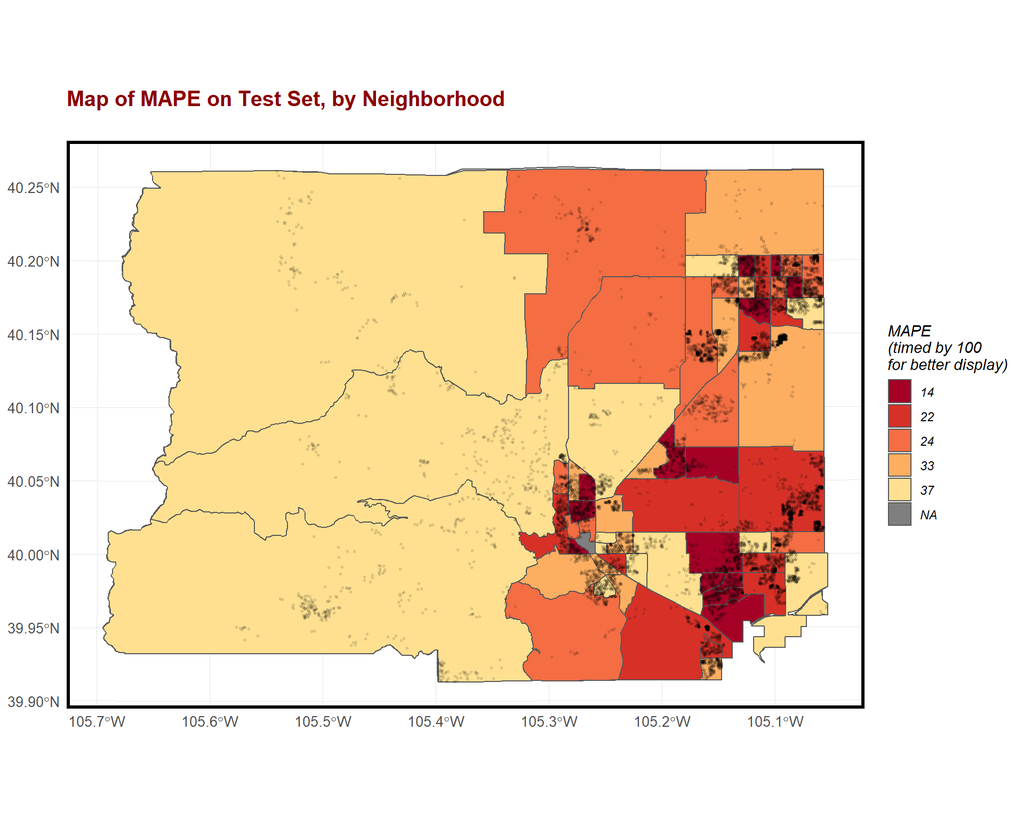

```r
nhood_sum <-model_test2%>%
  group_by(GEOID) %>%
  dplyr::summarize(meanPrice = mean(price, na.rm = T),
            meanPrediction = mean(SalePrice.Predict, na.rm = T),
            meanMAE = mean(SalePrice.AbsError, na.rm = T),
            meanMAPE = mean(SalePrice.APE,na.rm = T))

boulder.neigh.sum <- index.neigh %>%
  left_join(st_drop_geometry(nhood_sum), by = "GEOID") %>%
  mutate(meanMAPE.expanded = meanMAPE * 100)


boulder.sum <- tracts2019 %>%
  left_join(st_drop_geometry(nhood_sum), by = "GEOID") %>%
  mutate(meanMAPE.expanded = meanMAPE * 100)


map.MAPE.nhood <- ggplot() +
   geom_sf(data =boulder.boundary,fill = '#E5E5E5')+
  geom_sf(data = boulder.sum,
          aes(fill = q5(meanMAPE.expanded))) +
  scale_fill_manual(values=palette,
                     labels = qBr(boulder.neigh.sum,'meanMAPE.expanded'),
                     name = "MAPE\n(timed by 100\nfor better display)") +
   geom_sf(data = boulder.neigh.sum,color="black",size=0.5,alpha=0.1)+
  labs(title = 'Map of MAPE on Test Set, by Neighborhood\n') +
  mapTheme() +
  plotTheme()


map.MAPE.nhood
```

## 4.9 MAPE by neighborhood Here is a scatter plot shows MAPE by neighborhood. Neighborhood with mean sale price below or around 1200000 have relatively moderate and higher MAPE. As the price goes up, the MAPE goes down.

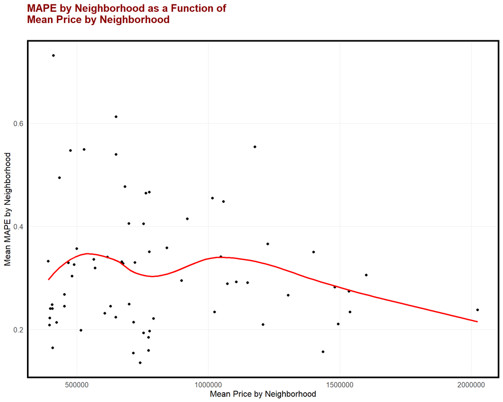

```r
MAPE.nhood.plot <-ggplot()+
  geom_point(data = nhood_sum, aes(x = meanPrice, y = meanMAPE)) +
  stat_smooth(data = nhood_sum, aes(x = meanPrice, y = meanMAPE), method = "loess", se = FALSE, size = 1, colour="red") +
  labs(title = "MAPE by Neighborhood as a Function of\nMean Price by Neighborhood\n") +
  xlab('Mean Price by Neighborhood') +
  ylab('Mean MAPE by Neighborhood') +
  plotTheme()
MAPE.nhood.plot
```